# Uge 4

## **Opgave** om en robot til sprøjtemaling af emner

En robot til sprøjtemaling laver utilsigtede ’helligdage’, d.v.s. små pletter, der ikke er blevet dækket af maling. Robotten laver i gennemsnit 0.8 helligdage per malet kvadrat meter. Robotten skal male 70 cirkelformede skiver på forsiden. Hver skive har en diameter på 1.2 m

### a. Hvor mange helligdage må der forventes at være på en tilfældig skive?

```r
A = pi * 0.6^2
lambda = A*0.8
cat("Der må forventes at være", lambda, "helligdage på en tilfældig skive")
```

```
## Der må forventes at være 0.9047787 helligdage på en tilfældig skive
```

### b. Hvilken sandsynlighedsfordeling vil du bruge til at beskrive antal helligdage på en skive, og hvad er fordelingens middelværdi, varians og standardafvigelse?

Da der ikke er en grænse for hvor mange pletter som kan være på en skive, og at der enten er eller ikke er en plet, vil antallet af helligdage kunne beskrives med en poisson-fordeling.

```r
mu = lambda
sigma = sqrt(lambda)
cat("Fordelingens middelværdi, varians, og standardafvigelse er hhv.", mu, sigma^2, sigma)
```

```
## Fordelingens middelværdi, varians, og standardafvigelse er hhv. 0.9047787 0.9047787 0.9511986
```

### c. Hvad er sandsynligheden for, at ingen af de 70 skiver har helligdage?

```r
dpois(0, lambda)
```

```
## [1] 0.4046314
```

### d. Beregn det forventede antal skiver med henholdsvis 0, 1, 2, 3 og 4 eller flere helligdage.

```r
1-ppois(-1,lambda)
```

```
## [1] 1
```

```r
1-ppois(0,lambda)
```

```
## [1] 0.5953686
```

```r
1-ppois(1,lambda)
```

```
## [1] 0.2292667
```

```r
1-ppois(2,lambda)
```

```
## [1] 0.06364609
```

```r
1-ppois(3,lambda)
```

```
## [1] 0.0136961
```

## Opgave om fjedres fjederkonstant

En dansk virksomhed er specialiseret i produktion af fjedre af mange forskellige typer og specifikationer. For en bestemt type galvaniseret trækfjeder oplyser virksomheden, at fjedre af denne type har en forventet fjederkonstant på 4.0 N/mm. Mere præcist oplyser virksomheden, at fjederkonstanten for fjedrene er normalfordelt med middelværdi 4.0 N/mm og standardafvigelse 0.1 N/mm.

Beregn følgende under forudsætning af, at virksomhedens oplysninger er korrekte:

### a. Beregn sandsynligheden for at en tilfældig fjeder af den omtalte type har en fjederkonstant på præcis 4.0 N/mm.

Da sandsynligheden modelleres med en kontinuær tæthedsfunktion og at integralet under funktionen bestemmer sandsynligheden, vil det betyde at enhver specifik værdi vil have en sandsynlighed på 0% for at optræde. Der vil kun være en ikke 0% sandsynlighed når der kigges på intervaller.

### b. Beregn sandsynligheden for at fjederens fjederkonstant er under 3.7 N/mm.

```r
mu = 4.0
sigma = 0.1

pnorm(3.7, mu, sigma)
```

```
## [1] 0.001349898
```

### c. Beregn sandsynligheden for at fjederens fjederkonstant er større end 4.1 N/mm.

```r
1 - pnorm(4.1, mu, sigma)
```

```
## [1] 0.1586553
```

### d. Beregn et interval omkring middelværdien, som 99% af fjedrene vil tilhøre.

```r
neg_z_alpha = qnorm(0.005, mu, sigma)
z_alpha = qnorm(0.995, mu, sigma)
cat("Intervallet, som 99% af fjedrene vil tilhøre er fra", neg_z_alpha, "til", z_alpha)
```

```
## Intervallet, som 99% af fjedrene vil tilhøre er fra 3.742417 til 4.257583
```

## **Eksamensopgave** 2022 1 om fordeling af bølgers højde

Selv i stabilt vejr er der stor variation i enkeltbølgers højde. En gruppe ingeniørstuderende vil undersøge hvordan højden af enkeltbølger fordeler sig. De registrerer 329 bølgers højde på det samme sted i løbet af 10 minutter på en dag med stille vejr. Tabellen nedenfor viser antal bølger fordelt efter højde i intervaller på 20 cm. F.eks. kan man se, at de studerende talte 22 bølger i intervallet mellem 1.0 og 1.2 meters bølgehøjde.

| Bølgehøjde (m) | Antal bølger |
| --- | --- |
| 0.0 - 0.2 | 25 |
| 0.2 - 0.4 | 65 |
| 0.4 - 0.6 | 84 |
| 0.6 - 0.8 | 71 |
| 0.8 - 1.0 | 46 |
| 1.0 - 1.2 | 22 |
| 1.2 - 1.4 | 13 |
| 1.4 - 1.6 | 3 |

### a. Omregn antal bølger i hvert interval til sandsynligheden for at få en bølge indenfor intervallet.

```r
D = read.table("Data_ECEStat_2022_opg1.csv", header=TRUE, sep=";")
FRA = D$Opg1_Hoejde_Fra
TIL = D$Opg1_Hoejde_Til
ANTAL = D$Opg1_Observeret_Antal

P_wave = ANTAL / sum(ANTAL)
D$P_wave = P_wave
D
```

```
##   Opg1_Hoejde_Fra Opg1_Hoejde_Til Opg1_Observeret_Antal      P_wave
## 1             0.0             0.2                    25 0.075987842
## 2             0.2             0.4                    65 0.197568389
## 3             0.4             0.6                    84 0.255319149
## 4             0.6             0.8                    71 0.215805471
## 5             0.8             1.0                    46 0.139817629
## 6             1.0             1.2                    22 0.066869301
## 7             1.2             1.4                    13 0.039513678
## 8             1.4             1.6                     3 0.009118541
```

### b. Beregn den kumulerede sandsynlighedsfordeling for bølgehøjden. Hvad er sandsynligheden for, at den næste bølge er højere end 0.8 m?

```r
P_wave_cum = cumsum(P_wave)
D$P_wave_cum = P_wave_cum
D
```

```
##   Opg1_Hoejde_Fra Opg1_Hoejde_Til Opg1_Observeret_Antal      P_wave P_wave_cum
## 1             0.0             0.2                    25 0.075987842 0.07598784
## 2             0.2             0.4                    65 0.197568389 0.27355623
## 3             0.4             0.6                    84 0.255319149 0.52887538
## 4             0.6             0.8                    71 0.215805471 0.74468085
## 5             0.8             1.0                    46 0.139817629 0.88449848
## 6             1.0             1.2                    22 0.066869301 0.95136778
## 7             1.2             1.4                    13 0.039513678 0.99088146
## 8             1.4             1.6                     3 0.009118541 1.00000000
```

```r
P_greater_8 = 1 - P_wave_cum[4]
P_greater_8
```

```
## [1] 0.2553191
```

### c. Beregn den gennemsnitlige bølgehøjde (antag at alle bølgerne i et interval har samme højde, nemlig intervallets midterværdi).

```r
mean_height = sum((FRA+TIL)/2 * ANTAL) / sum(ANTAL)
mean_height
```

```
## [1] 0.6100304
```

## **Eksamensopgave** 2023 2a-b om en F1 racers bremsekøling

Bremseevnen er ikke den eneste parameter, der er vigtig i valget af bremsefabrikat. Bremsernes evne til at køle bremseskiverne ned igen efter en opbremsning er lige så vigtig. Bremserne virker ved at overføre racerbilens bevægelsesenergi til friktion (varme). Ved en hård opbremsning stiger bremsernes temperatur med ca. 100 °C pr. tiendedel sekund, og temperaturen kan overstige 1000 °C efter en opbremsning. Bremserne virker bedst mellem 400 og 800 °C, og de tager skade over 1000 °C. Racerbilens kølesystem til bremserne skal effektivt fjerne varmen fra bremseskiverne, så de ikke tager skade, og så bremserne er klar til næste nedbremsning. Ingeniørerne fra MoneyGram Haas F1 Team har målt, hvor godt bremserne fra X Breaking Systems køler ned. For 800 nedbremsninger har de målt nedkølingen som temperaturfaldet ∆𝑡 i det første sekund efter bremsepedalen slippes. De 800 målinger af nedkølingen ∆𝑡 fordeler sig som vist i tabellen nedenfor.

| Nedkøling | Antal |
| --- | --- |
| $\Delta t < 150^{\circ}C$ | 35 |
| $150^{\circ}C ≤ \Delta𝑡 < 200^{\circ}C$ | 179 |
| $200^{\circ}C ≤ \Delta𝑡 < 250^{\circ}C$ | 351 |
| $250^{\circ}C ≤ \Delta𝑡 < 300^{\circ}C$ | 205 |
| $\Delta𝑡 \geq 300^{\circ}C$ | 30 |
| I Alt | 800 |

Ingeniørerne antager, at bremsernes køleevne, målt som ∆𝑡, kan modelleres statistisk som en normalfordeling. De har estimeret normalfordelingens middelværdi og standardafvigelse ud fra de 800 målinger til at være henholdsvis $\hat{\mu} = 229^{\circ}C$ og $\hat{\sigma} = 41^{\circ}C$. De ønsker at benytte en Goodness of Fit test til at afgøre, om antagelsen om normalfordeling er plausibel.

### a. Beregn – under forudsætning af ingeniørernes antagelse af en normalfordelt statistisk model – sandsynlighederne for at nedkølingen efter en opbremsning ligger indenfor temperaturintervallerne i tabellen. Du skal altså beregne de 5 sandsynligheder: P(∆t < 150 ℃), P(150 ℃ ≤ ∆t < 200 ℃), P(200 ℃ ≤ ∆t < 250 ℃), P(250 ℃ ≤ ∆t < 300 ℃), P(∆t ≥ 300 ℃).

```r
D = read.table("Data_ECEStat_2023_opg2.csv", header=TRUE, sep = ";")
ANTAL = D$ObserveretAntal
P_interval = ANTAL / 800
D$P_interval = P_interval
D
```

```
##   Temperaturinterval_tekst Temperaturinterval_nr ObserveretAntal P_interval
## 1                    t<150                     1              35    0.04375
## 2           150 <= t < 200                     2             179    0.22375
## 3           200 <= t < 250                     3             351    0.43875
## 4           250 <= t < 300                     4             205    0.25625
## 5                 t >= 300                     5              30    0.03750
```

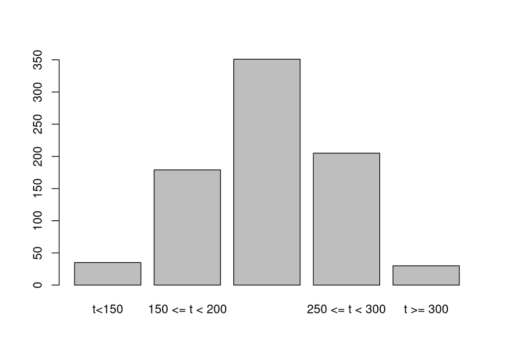

```r
barplot(ANTAL, names.arg = D$Temperaturinterval_tekst)
```

Yup det er en normalfordeling.

### b. Beregn under antagelse af ovennævnte normalfordeling det forventede antal nedbremsninger i hver af de fem temperaturintervaller, når der i alt foretages 800 nedbremsninger.